# Risk Factor Analysis

## Outcome Variable

**Outcome Variable:** ever_wasted

## Predictor Variables

**Intervention Variable:** meducyrs

**Adjustment Set:**

unadjusted

## Stratifying Variables

The analysis was stratified on these variable(s):

- agecat
- studyid
- country

## Data Summary

| agecat | studyid | country | meducyrs | ever_wasted | n_cell | n |
| --- | --- | --- | --- | --- | --- | --- |
| 0-24 months | ki0047075b-MAL-ED | BANGLADESH | High | 0 | 59 | 213 |
| 0-24 months | ki0047075b-MAL-ED | BANGLADESH | High | 1 | 19 | 213 |
| 0-24 months | ki0047075b-MAL-ED | BANGLADESH | Low | 0 | 46 | 213 |
| 0-24 months | ki0047075b-MAL-ED | BANGLADESH | Low | 1 | 24 | 213 |
| 0-24 months | ki0047075b-MAL-ED | BANGLADESH | Medium | 0 | 44 | 213 |
| 0-24 months | ki0047075b-MAL-ED | BANGLADESH | Medium | 1 | 21 | 213 |
| 0-24 months | ki0047075b-MAL-ED | BRAZIL | High | 0 | 76 | 232 |
| 0-24 months | ki0047075b-MAL-ED | BRAZIL | High | 1 | 3 | 232 |
| 0-24 months | ki0047075b-MAL-ED | BRAZIL | Low | 0 | 55 | 232 |
| 0-24 months | ki0047075b-MAL-ED | BRAZIL | Low | 1 | 8 | 232 |
| 0-24 months | ki0047075b-MAL-ED | BRAZIL | Medium | 0 | 82 | 232 |
| 0-24 months | ki0047075b-MAL-ED | BRAZIL | Medium | 1 | 8 | 232 |
| 0-24 months | ki0047075b-MAL-ED | INDIA | High | 0 | 39 | 220 |
| 0-24 months | ki0047075b-MAL-ED | INDIA | High | 1 | 24 | 220 |
| 0-24 months | ki0047075b-MAL-ED | INDIA | Low | 0 | 33 | 220 |
| 0-24 months | ki0047075b-MAL-ED | INDIA | Low | 1 | 43 | 220 |
| 0-24 months | ki0047075b-MAL-ED | INDIA | Medium | 0 | 44 | 220 |
| 0-24 months | ki0047075b-MAL-ED | INDIA | Medium | 1 | 37 | 220 |
| 0-24 months | ki0047075b-MAL-ED | NEPAL | High | 0 | 40 | 225 |
| 0-24 months | ki0047075b-MAL-ED | NEPAL | High | 1 | 13 | 225 |
| 0-24 months | ki0047075b-MAL-ED | NEPAL | Low | 0 | 69 | 225 |
| 0-24 months | ki0047075b-MAL-ED | NEPAL | Low | 1 | 27 | 225 |
| 0-24 months | ki0047075b-MAL-ED | NEPAL | Medium | 0 | 51 | 225 |
| 0-24 months | ki0047075b-MAL-ED | NEPAL | Medium | 1 | 25 | 225 |
| 0-24 months | ki0047075b-MAL-ED | PERU | High | 0 | 87 | 301 |
| 0-24 months | ki0047075b-MAL-ED | PERU | High | 1 | 3 | 301 |
| 0-24 months | ki0047075b-MAL-ED | PERU | Low | 0 | 93 | 301 |
| 0-24 months | ki0047075b-MAL-ED | PERU | Low | 1 | 11 | 301 |
| 0-24 months | ki0047075b-MAL-ED | PERU | Medium | 0 | 95 | 301 |
| 0-24 months | ki0047075b-MAL-ED | PERU | Medium | 1 | 12 | 301 |

[output cut: 438 more lines]

The following strata were considered:

- agecat: 0-24 months, studyid: ki0047075b-MAL-ED, country: BANGLADESH
- agecat: 0-24 months, studyid: ki0047075b-MAL-ED, country: BRAZIL
- agecat: 0-24 months, studyid: ki0047075b-MAL-ED, country: INDIA
- agecat: 0-24 months, studyid: ki0047075b-MAL-ED, country: NEPAL
- agecat: 0-24 months, studyid: ki0047075b-MAL-ED, country: PERU
- agecat: 0-24 months, studyid: ki0047075b-MAL-ED, country: SOUTH AFRICA
- agecat: 0-24 months, studyid: ki0047075b-MAL-ED, country: TANZANIA, UNITED REPUBLIC OF
- agecat: 0-24 months, studyid: ki1000108-CMC-V-BCS-2002, country: INDIA
- agecat: 0-24 months, studyid: ki1000108-IRC, country: INDIA
- agecat: 0-24 months, studyid: ki1000109-EE, country: PAKISTAN
- agecat: 0-24 months, studyid: ki1000304b-SAS-CompFeed, country: INDIA
- agecat: 0-24 months, studyid: ki1000304b-SAS-FoodSuppl, country: INDIA
- agecat: 0-24 months, studyid: ki1017093-NIH-Birth, country: BANGLADESH
- agecat: 0-24 months, studyid: ki1017093b-PROVIDE, country: BANGLADESH
- agecat: 0-24 months, studyid: ki1017093c-NIH-Crypto, country: BANGLADESH
- agecat: 0-24 months, studyid: ki1066203-TanzaniaChild2, country: TANZANIA, UNITED REPUBLIC OF
- agecat: 0-24 months, studyid: ki1112895-Guatemala BSC, country: GUATEMALA
- agecat: 0-24 months, studyid: ki1113344-GMS-Nepal, country: NEPAL
- agecat: 0-24 months, studyid: ki1119695-PROBIT, country: BELARUS
- agecat: 0-24 months, studyid: ki1126311-ZVITAMBO, country: ZIMBABWE
- agecat: 0-24 months, studyid: ki1135781-COHORTS, country: GUATEMALA
- agecat: 0-24 months, studyid: ki1135781-COHORTS, country: INDIA
- agecat: 0-24 months, studyid: ki1135781-COHORTS, country: PHILIPPINES
- agecat: 0-24 months, studyid: ki1148112-LCNI-5, country: MALAWI
- agecat: 0-24 months, studyid: kiGH5241-JiVitA-3, country: BANGLADESH
- agecat: 0-24 months, studyid: kiGH5241-JiVitA-4, country: BANGLADESH
- agecat: 0-6 months, studyid: ki0047075b-MAL-ED, country: BANGLADESH
- agecat: 0-6 months, studyid: ki0047075b-MAL-ED, country: BRAZIL
- agecat: 0-6 months, studyid: ki0047075b-MAL-ED, country: INDIA
- agecat: 0-6 months, studyid: ki0047075b-MAL-ED, country: NEPAL
- agecat: 0-6 months, studyid: ki0047075b-MAL-ED, country: PERU
- agecat: 0-6 months, studyid: ki0047075b-MAL-ED, country: SOUTH AFRICA
- agecat: 0-6 months, studyid: ki0047075b-MAL-ED, country: TANZANIA, UNITED REPUBLIC OF
- agecat: 0-6 months, studyid: ki1000108-CMC-V-BCS-2002, country: INDIA
- agecat: 0-6 months, studyid: ki1000108-IRC, country: INDIA
- agecat: 0-6 months, studyid: ki1000109-EE, country: PAKISTAN
- agecat: 0-6 months, studyid: ki1000304b-SAS-CompFeed, country: INDIA
- agecat: 0-6 months, studyid: ki1000304b-SAS-FoodSuppl, country: INDIA
- agecat: 0-6 months, studyid: ki1017093-NIH-Birth, country: BANGLADESH
- agecat: 0-6 months, studyid: ki1017093b-PROVIDE, country: BANGLADESH
- agecat: 0-6 months, studyid: ki1017093c-NIH-Crypto, country: BANGLADESH
- agecat: 0-6 months, studyid: ki1066203-TanzaniaChild2, country: TANZANIA, UNITED REPUBLIC OF
- agecat: 0-6 months, studyid: ki1112895-Guatemala BSC, country: GUATEMALA
- agecat: 0-6 months, studyid: ki1113344-GMS-Nepal, country: NEPAL
- agecat: 0-6 months, studyid: ki1119695-PROBIT, country: BELARUS
- agecat: 0-6 months, studyid: ki1126311-ZVITAMBO, country: ZIMBABWE
- agecat: 0-6 months, studyid: ki1135781-COHORTS, country: GUATEMALA
- agecat: 0-6 months, studyid: ki1135781-COHORTS, country: INDIA
- agecat: 0-6 months, studyid: ki1135781-COHORTS, country: PHILIPPINES
- agecat: 0-6 months, studyid: ki1148112-LCNI-5, country: MALAWI
- agecat: 0-6 months, studyid: kiGH5241-JiVitA-3, country: BANGLADESH
- agecat: 0-6 months, studyid: kiGH5241-JiVitA-4, country: BANGLADESH
- agecat: 6-24 months, studyid: ki0047075b-MAL-ED, country: BANGLADESH
- agecat: 6-24 months, studyid: ki0047075b-MAL-ED, country: BRAZIL
- agecat: 6-24 months, studyid: ki0047075b-MAL-ED, country: INDIA
- agecat: 6-24 months, studyid: ki0047075b-MAL-ED, country: NEPAL
- agecat: 6-24 months, studyid: ki0047075b-MAL-ED, country: PERU
- agecat: 6-24 months, studyid: ki0047075b-MAL-ED, country: SOUTH AFRICA
- agecat: 6-24 months, studyid: ki0047075b-MAL-ED, country: TANZANIA, UNITED REPUBLIC OF
- agecat: 6-24 months, studyid: ki1000108-CMC-V-BCS-2002, country: INDIA
- agecat: 6-24 months, studyid: ki1000108-IRC, country: INDIA
- agecat: 6-24 months, studyid: ki1000109-EE, country: PAKISTAN
- agecat: 6-24 months, studyid: ki1000304b-SAS-CompFeed, country: INDIA
- agecat: 6-24 months, studyid: ki1000304b-SAS-FoodSuppl, country: INDIA
- agecat: 6-24 months, studyid: ki1017093-NIH-Birth, country: BANGLADESH
- agecat: 6-24 months, studyid: ki1017093b-PROVIDE, country: BANGLADESH
- agecat: 6-24 months, studyid: ki1017093c-NIH-Crypto, country: BANGLADESH
- agecat: 6-24 months, studyid: ki1066203-TanzaniaChild2, country: TANZANIA, UNITED REPUBLIC OF
- agecat: 6-24 months, studyid: ki1112895-Guatemala BSC, country: GUATEMALA
- agecat: 6-24 months, studyid: ki1113344-GMS-Nepal, country: NEPAL
- agecat: 6-24 months, studyid: ki1119695-PROBIT, country: BELARUS
- agecat: 6-24 months, studyid: ki1126311-ZVITAMBO, country: ZIMBABWE
- agecat: 6-24 months, studyid: ki1135781-COHORTS, country: GUATEMALA
- agecat: 6-24 months, studyid: ki1135781-COHORTS, country: INDIA
- agecat: 6-24 months, studyid: ki1135781-COHORTS, country: PHILIPPINES
- agecat: 6-24 months, studyid: ki1148112-LCNI-5, country: MALAWI
- agecat: 6-24 months, studyid: kiGH5241-JiVitA-3, country: BANGLADESH
- agecat: 6-24 months, studyid: kiGH5241-JiVitA-4, country: BANGLADESH

### Dropped Strata

Some strata were dropped due to rare outcomes:

- agecat: 0-24 months, studyid: ki0047075b-MAL-ED, country: BRAZIL
- agecat: 0-24 months, studyid: ki0047075b-MAL-ED, country: PERU
- agecat: 0-24 months, studyid: ki0047075b-MAL-ED, country: TANZANIA, UNITED REPUBLIC OF
- agecat: 0-24 months, studyid: ki1000304b-SAS-FoodSuppl, country: INDIA
- agecat: 0-24 months, studyid: kiGH5241-JiVitA-4, country: BANGLADESH
- agecat: 0-6 months, studyid: ki0047075b-MAL-ED, country: BRAZIL
- agecat: 0-6 months, studyid: ki0047075b-MAL-ED, country: PERU
- agecat: 0-6 months, studyid: ki0047075b-MAL-ED, country: TANZANIA, UNITED REPUBLIC OF
- agecat: 0-6 months, studyid: ki1000109-EE, country: PAKISTAN
- agecat: 0-6 months, studyid: ki1000304b-SAS-FoodSuppl, country: INDIA
- agecat: 0-6 months, studyid: ki1112895-Guatemala BSC, country: GUATEMALA
- agecat: 0-6 months, studyid: ki1148112-LCNI-5, country: MALAWI
- agecat: 0-6 months, studyid: kiGH5241-JiVitA-4, country: BANGLADESH
- agecat: 6-24 months, studyid: ki0047075b-MAL-ED, country: BRAZIL
- agecat: 6-24 months, studyid: ki0047075b-MAL-ED, country: PERU
- agecat: 6-24 months, studyid: ki0047075b-MAL-ED, country: TANZANIA, UNITED REPUBLIC OF
- agecat: 6-24 months, studyid: ki1000109-EE, country: PAKISTAN
- agecat: 6-24 months, studyid: ki1000304b-SAS-FoodSuppl, country: INDIA
- agecat: 6-24 months, studyid: ki1112895-Guatemala BSC, country: GUATEMALA
- agecat: 6-24 months, studyid: kiGH5241-JiVitA-4, country: BANGLADESH

## Methods Detail

We’re interested in the causal parameters $E[Y_a]$ for all values of $a \in \mathcal{A}$. These parameters represent the mean outcome if, possibly contrary to fact, we intervened to set all units to have $A=a$. Under the randomization and positivity assumptions, these are identified by the statistical parameters $\psi_a=E_W[E_{Y|A,W}(Y|A=a,W)]$. In addition, we’re interested in the mean of $Y$, $E[Y]$ under no intervention (the observed mean). We will estimate these parameters by using SuperLearner to fit the relevant likelihood factors – $E_{Y|A,W}(Y|A=a,W)$ and $p(A=a|W)$, and then updating our likelihood fit using a joint TMLE.

For unadjusted analyses ($W=\{\}$), initial likelihoods were estimated using Lrnr_glm to estimate the simple $E(Y|A)$ and Lrnr_mean to estimate $p(A)$. For adjusted analyses, a small library containing Lrnr_glmnet, Lrnr_xgboost, and Lrnr_mean was used.

Having estimated these parameters, we will then use the delta method to estimate relative risks and attributable risks relative to a prespecified baseline level of $A$.

# Results Detail

## Results Plots

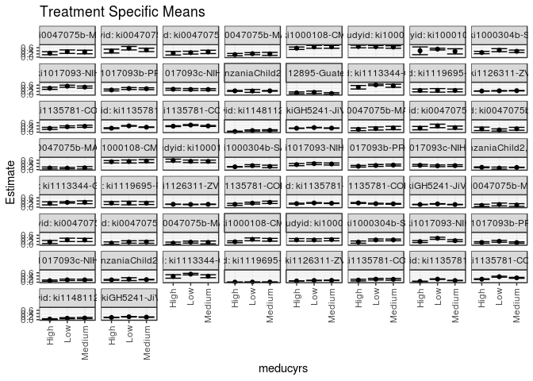

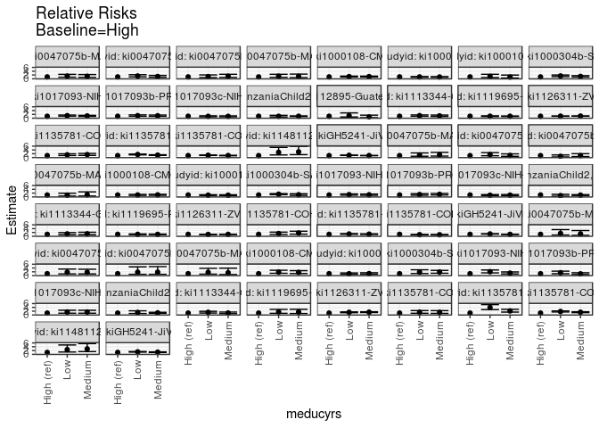

[figure not shown]

[figure not shown]

## Results Table

### Parameter: TSM

| agecat | studyid | country | intervention_level | baseline_level | estimate | ci_lower | ci_upper |
| --- | --- | --- | --- | --- | --- | --- | --- |
| 0-24 months | ki0047075b-MAL-ED | BANGLADESH | High | NA | 0.2435897 | 0.1481057 | 0.3390738 |
| 0-24 months | ki0047075b-MAL-ED | BANGLADESH | Low | NA | 0.3428571 | 0.2314001 | 0.4543142 |
| 0-24 months | ki0047075b-MAL-ED | BANGLADESH | Medium | NA | 0.3230769 | 0.2091213 | 0.4370326 |
| 0-24 months | ki0047075b-MAL-ED | INDIA | High | NA | 0.3809524 | 0.2607634 | 0.5011413 |
| 0-24 months | ki0047075b-MAL-ED | INDIA | Low | NA | 0.5657895 | 0.4541010 | 0.6774779 |
| 0-24 months | ki0047075b-MAL-ED | INDIA | Medium | NA | 0.4567901 | 0.3480632 | 0.5655170 |
| 0-24 months | ki0047075b-MAL-ED | NEPAL | High | NA | 0.2452830 | 0.1291908 | 0.3613753 |
| 0-24 months | ki0047075b-MAL-ED | NEPAL | Low | NA | 0.2812500 | 0.1911105 | 0.3713895 |
| 0-24 months | ki0047075b-MAL-ED | NEPAL | Medium | NA | 0.3289474 | 0.2230829 | 0.4348118 |
| 0-24 months | ki0047075b-MAL-ED | SOUTH AFRICA | High | NA | 0.1578947 | 0.0844517 | 0.2313377 |
| 0-24 months | ki0047075b-MAL-ED | SOUTH AFRICA | Low | NA | 0.2162162 | 0.1497874 | 0.2826450 |
| 0-24 months | ki0047075b-MAL-ED | SOUTH AFRICA | Medium | NA | 0.2028986 | 0.1078563 | 0.2979408 |
| 0-24 months | ki1000108-CMC-V-BCS-2002 | INDIA | High | NA | 0.5632911 | 0.4858512 | 0.6407311 |
| 0-24 months | ki1000108-CMC-V-BCS-2002 | INDIA | Low | NA | 0.6509434 | 0.5600782 | 0.7418086 |
| 0-24 months | ki1000108-CMC-V-BCS-2002 | INDIA | Medium | NA | 0.6513761 | 0.5617959 | 0.7409564 |
| 0-24 months | ki1000108-IRC | INDIA | High | NA | 0.6693548 | 0.5864506 | 0.7522591 |
| 0-24 months | ki1000108-IRC | INDIA | Low | NA | 0.6598639 | 0.5831855 | 0.7365424 |
| 0-24 months | ki1000108-IRC | INDIA | Medium | NA | 0.6402878 | 0.5604081 | 0.7201674 |
| 0-24 months | ki1000109-EE | PAKISTAN | High | NA | 0.4000000 | 0.1517525 | 0.6482475 |
| 0-24 months | ki1000109-EE | PAKISTAN | Low | NA | 0.5075988 | 0.4535051 | 0.5616925 |
| 0-24 months | ki1000109-EE | PAKISTAN | Medium | NA | 0.3636364 | 0.1992922 | 0.5279805 |
| 0-24 months | ki1000304b-SAS-CompFeed | INDIA | High | NA | 0.2900000 | 0.2160725 | 0.3639275 |
| 0-24 months | ki1000304b-SAS-CompFeed | INDIA | Low | NA | 0.4390244 | 0.3423088 | 0.5357400 |
| 0-24 months | ki1000304b-SAS-CompFeed | INDIA | Medium | NA | 0.3670886 | 0.2892617 | 0.4449155 |
| 0-24 months | ki1017093-NIH-Birth | BANGLADESH | High | NA | 0.4044944 | 0.3323362 | 0.4766526 |
| 0-24 months | ki1017093-NIH-Birth | BANGLADESH | Low | NA | 0.5350877 | 0.4702949 | 0.5998805 |
| 0-24 months | ki1017093-NIH-Birth | BANGLADESH | Medium | NA | 0.4770642 | 0.4107081 | 0.5434203 |
| 0-24 months | ki1017093b-PROVIDE | BANGLADESH | High | NA | 0.2936170 | 0.2353483 | 0.3518857 |
| 0-24 months | ki1017093b-PROVIDE | BANGLADESH | Low | NA | 0.3878505 | 0.3225205 | 0.4531805 |
| 0-24 months | ki1017093b-PROVIDE | BANGLADESH | Medium | NA | 0.3745020 | 0.3145834 | 0.4344206 |

[output cut: 144 more lines]

### Parameter: E(Y)

| agecat | studyid | country | intervention_level | baseline_level | estimate | ci_lower | ci_upper |
| --- | --- | --- | --- | --- | --- | --- | --- |
| 0-24 months | ki0047075b-MAL-ED | BANGLADESH | NA | NA | 0.3004695 | 0.2387555 | 0.3621835 |
| 0-24 months | ki0047075b-MAL-ED | INDIA | NA | NA | 0.4727273 | 0.4066048 | 0.5388497 |
| 0-24 months | ki0047075b-MAL-ED | NEPAL | NA | NA | 0.2888889 | 0.2295338 | 0.3482440 |
| 0-24 months | ki0047075b-MAL-ED | SOUTH AFRICA | NA | NA | 0.1955128 | 0.1514355 | 0.2395901 |
| 0-24 months | ki1000108-CMC-V-BCS-2002 | INDIA | NA | NA | 0.6139410 | 0.5644682 | 0.6634139 |
| 0-24 months | ki1000108-IRC | INDIA | NA | NA | 0.6560976 | 0.6100625 | 0.7021326 |
| 0-24 months | ki1000109-EE | PAKISTAN | NA | NA | 0.4907162 | 0.4401862 | 0.5412462 |
| 0-24 months | ki1000304b-SAS-CompFeed | INDIA | NA | NA | 0.3822894 | 0.3008363 | 0.4637425 |
| 0-24 months | ki1017093-NIH-Birth | BANGLADESH | NA | NA | 0.4775641 | 0.4383415 | 0.5167867 |
| 0-24 months | ki1017093b-PROVIDE | BANGLADESH | NA | NA | 0.3514286 | 0.3160364 | 0.3868207 |
| 0-24 months | ki1017093c-NIH-Crypto | BANGLADESH | NA | NA | 0.3311346 | 0.2976093 | 0.3646598 |
| 0-24 months | ki1066203-TanzaniaChild2 | TANZANIA, UNITED REPUBLIC OF | NA | NA | 0.2367980 | 0.2197367 | 0.2538593 |
| 0-24 months | ki1112895-Guatemala BSC | GUATEMALA | NA | NA | 0.1063830 | 0.0703329 | 0.1424331 |
| 0-24 months | ki1113344-GMS-Nepal | NEPAL | NA | NA | 0.5909850 | 0.5515796 | 0.6303903 |
| 0-24 months | ki1119695-PROBIT | BELARUS | NA | NA | 0.2655346 | 0.1719990 | 0.3590703 |
| 0-24 months | ki1126311-ZVITAMBO | ZIMBABWE | NA | NA | 0.2346433 | 0.2276029 | 0.2416837 |
| 0-24 months | ki1135781-COHORTS | GUATEMALA | NA | NA | 0.3235294 | 0.2874259 | 0.3596329 |
| 0-24 months | ki1135781-COHORTS | INDIA | NA | NA | 0.3329911 | 0.3209071 | 0.3450751 |
| 0-24 months | ki1135781-COHORTS | PHILIPPINES | NA | NA | 0.4036125 | 0.3861835 | 0.4210415 |
| 0-24 months | ki1148112-LCNI-5 | MALAWI | NA | NA | 0.0798526 | 0.0612199 | 0.0984853 |
| 0-24 months | kiGH5241-JiVitA-3 | BANGLADESH | NA | NA | 0.2642771 | 0.2551890 | 0.2733653 |
| 0-6 months | ki0047075b-MAL-ED | BANGLADESH | NA | NA | 0.2206573 | 0.1648355 | 0.2764790 |
| 0-6 months | ki0047075b-MAL-ED | INDIA | NA | NA | 0.3136364 | 0.2521871 | 0.3750856 |
| 0-6 months | ki0047075b-MAL-ED | NEPAL | NA | NA | 0.1777778 | 0.1277101 | 0.2278455 |
| 0-6 months | ki0047075b-MAL-ED | SOUTH AFRICA | NA | NA | 0.1025641 | 0.0688457 | 0.1362825 |
| 0-6 months | ki1000108-CMC-V-BCS-2002 | INDIA | NA | NA | 0.5190217 | 0.4679041 | 0.5701394 |
| 0-6 months | ki1000108-IRC | INDIA | NA | NA | 0.5439024 | 0.4956326 | 0.5921723 |
| 0-6 months | ki1000304b-SAS-CompFeed | INDIA | NA | NA | 0.2207792 | 0.1636864 | 0.2778721 |
| 0-6 months | ki1017093-NIH-Birth | BANGLADESH | NA | NA | 0.3569132 | 0.3192325 | 0.3945938 |
| 0-6 months | ki1017093b-PROVIDE | BANGLADESH | NA | NA | 0.2585714 | 0.2261125 | 0.2910304 |
| 0-6 months | ki1017093c-NIH-Crypto | BANGLADESH | NA | NA | 0.2585752 | 0.2273844 | 0.2897660 |
| 0-6 months | ki1066203-TanzaniaChild2 | TANZANIA, UNITED REPUBLIC OF | NA | NA | 0.1395641 | 0.1256566 | 0.1534717 |
| 0-6 months | ki1113344-GMS-Nepal | NEPAL | NA | NA | 0.2954925 | 0.2589234 | 0.3320615 |
| 0-6 months | ki1119695-PROBIT | BELARUS | NA | NA | 0.2599065 | 0.1654090 | 0.3544039 |
| 0-6 months | ki1126311-ZVITAMBO | ZIMBABWE | NA | NA | 0.1809503 | 0.1745333 | 0.1873674 |
| 0-6 months | ki1135781-COHORTS | GUATEMALA | NA | NA | 0.2500000 | 0.2121588 | 0.2878412 |
| 0-6 months | ki1135781-COHORTS | INDIA | NA | NA | 0.2511554 | 0.2398221 | 0.2624886 |
| 0-6 months | ki1135781-COHORTS | PHILIPPINES | NA | NA | 0.2355453 | 0.2204685 | 0.2506222 |
| 0-6 months | kiGH5241-JiVitA-3 | BANGLADESH | NA | NA | 0.1822913 | 0.1742792 | 0.1903033 |
| 6-24 months | ki0047075b-MAL-ED | BANGLADESH | NA | NA | 0.1384615 | 0.0898601 | 0.1870630 |
| 6-24 months | ki0047075b-MAL-ED | INDIA | NA | NA | 0.2657005 | 0.2053824 | 0.3260185 |
| 6-24 months | ki0047075b-MAL-ED | NEPAL | NA | NA | 0.1545455 | 0.1066715 | 0.2024194 |
| 6-24 months | ki0047075b-MAL-ED | SOUTH AFRICA | NA | NA | 0.1389961 | 0.0967835 | 0.1812087 |
| 6-24 months | ki1000108-CMC-V-BCS-2002 | INDIA | NA | NA | 0.2654155 | 0.2205451 | 0.3102860 |
| 6-24 months | ki1000108-IRC | INDIA | NA | NA | 0.3097561 | 0.2649438 | 0.3545684 |
| 6-24 months | ki1000304b-SAS-CompFeed | INDIA | NA | NA | 0.2708333 | 0.2169112 | 0.3247555 |
| 6-24 months | ki1017093-NIH-Birth | BANGLADESH | NA | NA | 0.2939002 | 0.2554778 | 0.3323226 |
| 6-24 months | ki1017093b-PROVIDE | BANGLADESH | NA | NA | 0.1609756 | 0.1319065 | 0.1900447 |
| 6-24 months | ki1017093c-NIH-Crypto | BANGLADESH | NA | NA | 0.1315069 | 0.1069744 | 0.1560393 |
| 6-24 months | ki1066203-TanzaniaChild2 | TANZANIA, UNITED REPUBLIC OF | NA | NA | 0.1606166 | 0.1445647 | 0.1766685 |
| 6-24 months | ki1113344-GMS-Nepal | NEPAL | NA | NA | 0.4735945 | 0.4331684 | 0.5140207 |
| 6-24 months | ki1119695-PROBIT | BELARUS | NA | NA | 0.0082759 | 0.0065972 | 0.0099545 |
| 6-24 months | ki1126311-ZVITAMBO | ZIMBABWE | NA | NA | 0.0940163 | 0.0884807 | 0.0995519 |
| 6-24 months | ki1135781-COHORTS | GUATEMALA | NA | NA | 0.1737649 | 0.1430865 | 0.2044433 |
| 6-24 months | ki1135781-COHORTS | INDIA | NA | NA | 0.1266654 | 0.1178579 | 0.1354730 |
| 6-24 months | ki1135781-COHORTS | PHILIPPINES | NA | NA | 0.2666429 | 0.2502871 | 0.2829988 |
| 6-24 months | ki1148112-LCNI-5 | MALAWI | NA | NA | 0.0772105 | 0.0587369 | 0.0956840 |
| 6-24 months | kiGH5241-JiVitA-3 | BANGLADESH | NA | NA | 0.1649110 | 0.1557149 | 0.1741072 |

### Parameter: RR

| agecat | studyid | country | intervention_level | baseline_level | estimate | ci_lower | ci_upper |
| --- | --- | --- | --- | --- | --- | --- | --- |
| 0-24 months | ki0047075b-MAL-ED | BANGLADESH | High | High | 1.0000000 | 1.0000000 | 1.0000000 |
| 0-24 months | ki0047075b-MAL-ED | BANGLADESH | Low | High | 1.4075188 | 0.8458452 | 2.3421652 |
| 0-24 months | ki0047075b-MAL-ED | BANGLADESH | Medium | High | 1.3263158 | 0.7827719 | 2.2472876 |
| 0-24 months | ki0047075b-MAL-ED | INDIA | High | High | 1.0000000 | 1.0000000 | 1.0000000 |
| 0-24 months | ki0047075b-MAL-ED | INDIA | Low | High | 1.4851974 | 1.0236599 | 2.1548282 |
| 0-24 months | ki0047075b-MAL-ED | INDIA | Medium | High | 1.1990741 | 0.8076205 | 1.7802651 |
| 0-24 months | ki0047075b-MAL-ED | NEPAL | High | High | 1.0000000 | 1.0000000 | 1.0000000 |
| 0-24 months | ki0047075b-MAL-ED | NEPAL | Low | High | 1.1466346 | 0.6474126 | 2.0308084 |
| 0-24 months | ki0047075b-MAL-ED | NEPAL | Medium | High | 1.3410931 | 0.7566416 | 2.3769917 |
| 0-24 months | ki0047075b-MAL-ED | SOUTH AFRICA | High | High | 1.0000000 | 1.0000000 | 1.0000000 |
| 0-24 months | ki0047075b-MAL-ED | SOUTH AFRICA | Low | High | 1.3693694 | 0.7841961 | 2.3912036 |
| 0-24 months | ki0047075b-MAL-ED | SOUTH AFRICA | Medium | High | 1.2850242 | 0.6640788 | 2.4865829 |
| 0-24 months | ki1000108-CMC-V-BCS-2002 | INDIA | High | High | 1.0000000 | 1.0000000 | 1.0000000 |
| 0-24 months | ki1000108-CMC-V-BCS-2002 | INDIA | Low | High | 1.1556074 | 0.9499974 | 1.4057180 |
| 0-24 months | ki1000108-CMC-V-BCS-2002 | INDIA | Medium | High | 1.1563756 | 0.9520238 | 1.4045916 |
| 0-24 months | ki1000108-IRC | INDIA | High | High | 1.0000000 | 1.0000000 | 1.0000000 |
| 0-24 months | ki1000108-IRC | INDIA | Low | High | 0.9858208 | 0.8318400 | 1.1683049 |
| 0-24 months | ki1000108-IRC | INDIA | Medium | High | 0.9565745 | 0.8023635 | 1.1404243 |
| 0-24 months | ki1000109-EE | PAKISTAN | High | High | 1.0000000 | 1.0000000 | 1.0000000 |
| 0-24 months | ki1000109-EE | PAKISTAN | Low | High | 1.2689970 | 0.6760590 | 2.3819715 |
| 0-24 months | ki1000109-EE | PAKISTAN | Medium | High | 0.9090909 | 0.4218738 | 1.9589894 |
| 0-24 months | ki1000304b-SAS-CompFeed | INDIA | High | High | 1.0000000 | 1.0000000 | 1.0000000 |
| 0-24 months | ki1000304b-SAS-CompFeed | INDIA | Low | High | 1.5138772 | 1.1476000 | 1.9970583 |
| 0-24 months | ki1000304b-SAS-CompFeed | INDIA | Medium | High | 1.2658228 | 0.9557917 | 1.6764189 |
| 0-24 months | ki1017093-NIH-Birth | BANGLADESH | High | High | 1.0000000 | 1.0000000 | 1.0000000 |
| 0-24 months | ki1017093-NIH-Birth | BANGLADESH | Low | High | 1.3228558 | 1.0662922 | 1.6411518 |
| 0-24 months | ki1017093-NIH-Birth | BANGLADESH | Medium | High | 1.1794088 | 0.9406400 | 1.4787858 |
| 0-24 months | ki1017093b-PROVIDE | BANGLADESH | High | High | 1.0000000 | 1.0000000 | 1.0000000 |
| 0-24 months | ki1017093b-PROVIDE | BANGLADESH | Low | High | 1.3209400 | 1.0182088 | 1.7136785 |
| 0-24 months | ki1017093b-PROVIDE | BANGLADESH | Medium | High | 1.2754778 | 0.9884731 | 1.6458147 |

[output cut: 144 more lines]

### Parameter: PAR

| agecat | studyid | country | intervention_level | baseline_level | estimate | ci_lower | ci_upper |
| --- | --- | --- | --- | --- | --- | --- | --- |
| 0-24 months | ki0047075b-MAL-ED | BANGLADESH | High | NA | 0.0568797 | -0.0221673 | 0.1359268 |
| 0-24 months | ki0047075b-MAL-ED | INDIA | High | NA | 0.0917749 | -0.0109105 | 0.1944603 |
| 0-24 months | ki0047075b-MAL-ED | NEPAL | High | NA | 0.0436059 | -0.0595982 | 0.1468100 |
| 0-24 months | ki0047075b-MAL-ED | SOUTH AFRICA | High | NA | 0.0376181 | -0.0260369 | 0.1012730 |
| 0-24 months | ki1000108-CMC-V-BCS-2002 | INDIA | High | NA | 0.0506499 | -0.0073500 | 0.1086497 |
| 0-24 months | ki1000108-IRC | INDIA | High | NA | -0.0132573 | -0.0827910 | 0.0562765 |
| 0-24 months | ki1000109-EE | PAKISTAN | High | NA | 0.0907162 | -0.1527507 | 0.3341830 |
| 0-24 months | ki1000304b-SAS-CompFeed | INDIA | High | NA | 0.0922894 | 0.0172252 | 0.1673537 |
| 0-24 months | ki1017093-NIH-Birth | BANGLADESH | High | NA | 0.0730697 | 0.0116314 | 0.1345080 |
| 0-24 months | ki1017093b-PROVIDE | BANGLADESH | High | NA | 0.0578116 | 0.0091476 | 0.1064755 |
| 0-24 months | ki1017093c-NIH-Crypto | BANGLADESH | High | NA | -0.0113851 | -0.0588060 | 0.0360358 |
| 0-24 months | ki1066203-TanzaniaChild2 | TANZANIA, UNITED REPUBLIC OF | High | NA | 0.0000830 | -0.0286781 | 0.0288441 |
| 0-24 months | ki1112895-Guatemala BSC | GUATEMALA | High | NA | -0.0037865 | -0.0464720 | 0.0388989 |
| 0-24 months | ki1113344-GMS-Nepal | NEPAL | High | NA | 0.1243183 | 0.0188460 | 0.2297906 |
| 0-24 months | ki1119695-PROBIT | BELARUS | High | NA | 0.0020475 | -0.0231427 | 0.0272377 |
| 0-24 months | ki1126311-ZVITAMBO | ZIMBABWE | High | NA | 0.0080508 | 0.0015709 | 0.0145307 |
| 0-24 months | ki1135781-COHORTS | GUATEMALA | High | NA | 0.0835294 | 0.0274856 | 0.1395733 |
| 0-24 months | ki1135781-COHORTS | INDIA | High | NA | 0.0845674 | 0.0561925 | 0.1129423 |
| 0-24 months | ki1135781-COHORTS | PHILIPPINES | High | NA | 0.0260440 | 0.0040486 | 0.0480394 |
| 0-24 months | ki1148112-LCNI-5 | MALAWI | High | NA | 0.0429398 | 0.0212590 | 0.0646207 |
| 0-24 months | kiGH5241-JiVitA-3 | BANGLADESH | High | NA | 0.0180168 | 0.0072323 | 0.0288013 |
| 0-6 months | ki0047075b-MAL-ED | BANGLADESH | High | NA | 0.0411701 | -0.0300070 | 0.1123472 |
| 0-6 months | ki0047075b-MAL-ED | INDIA | High | NA | 0.0596681 | -0.0337920 | 0.1531283 |
| 0-6 months | ki0047075b-MAL-ED | NEPAL | High | NA | -0.0297694 | -0.1237895 | 0.0642507 |
| 0-6 months | ki0047075b-MAL-ED | SOUTH AFRICA | High | NA | -0.0026991 | -0.0539914 | 0.0485933 |
| 0-6 months | ki1000108-CMC-V-BCS-2002 | INDIA | High | NA | 0.0158370 | -0.0434337 | 0.0751078 |
| 0-6 months | ki1000108-IRC | INDIA | High | NA | -0.0367427 | -0.1096661 | 0.0361807 |
| 0-6 months | ki1000304b-SAS-CompFeed | INDIA | High | NA | 0.0407792 | -0.0108160 | 0.0923744 |
| 0-6 months | ki1017093-NIH-Birth | BANGLADESH | High | NA | 0.0348793 | -0.0239828 | 0.0937414 |
| 0-6 months | ki1017093b-PROVIDE | BANGLADESH | High | NA | 0.0415502 | -0.0028069 | 0.0859072 |
| 0-6 months | ki1017093c-NIH-Crypto | BANGLADESH | High | NA | -0.0170154 | -0.0614001 | 0.0273694 |
| 0-6 months | ki1066203-TanzaniaChild2 | TANZANIA, UNITED REPUBLIC OF | High | NA | -0.0069737 | -0.0307331 | 0.0167856 |
| 0-6 months | ki1113344-GMS-Nepal | NEPAL | High | NA | 0.0554925 | -0.0358964 | 0.1468814 |
| 0-6 months | ki1119695-PROBIT | BELARUS | High | NA | -0.0004532 | -0.0255791 | 0.0246727 |
| 0-6 months | ki1126311-ZVITAMBO | ZIMBABWE | High | NA | -0.0022008 | -0.0080879 | 0.0036862 |
| 0-6 months | ki1135781-COHORTS | GUATEMALA | High | NA | 0.0708955 | 0.0125045 | 0.1292866 |
| 0-6 months | ki1135781-COHORTS | INDIA | High | NA | 0.0271554 | -0.0008000 | 0.0551107 |
| 0-6 months | ki1135781-COHORTS | PHILIPPINES | High | NA | -0.0307218 | -0.0501334 | -0.0113102 |
| 0-6 months | kiGH5241-JiVitA-3 | BANGLADESH | High | NA | 0.0132330 | 0.0038097 | 0.0226562 |
| 6-24 months | ki0047075b-MAL-ED | BANGLADESH | High | NA | 0.0257855 | -0.0361817 | 0.0877527 |
| 6-24 months | ki0047075b-MAL-ED | INDIA | High | NA | 0.0932867 | 0.0048956 | 0.1816778 |
| 6-24 months | ki0047075b-MAL-ED | NEPAL | High | NA | 0.0583916 | -0.0170578 | 0.1338410 |
| 6-24 months | ki0047075b-MAL-ED | SOUTH AFRICA | High | NA | 0.0444015 | -0.0163828 | 0.1051859 |
| 6-24 months | ki1000108-CMC-V-BCS-2002 | INDIA | High | NA | 0.0818712 | 0.0311600 | 0.1325825 |
| 6-24 months | ki1000108-IRC | INDIA | High | NA | 0.0033045 | -0.0646376 | 0.0712466 |
| 6-24 months | ki1000304b-SAS-CompFeed | INDIA | High | NA | 0.1075680 | 0.0444109 | 0.1707251 |
| 6-24 months | ki1017093-NIH-Birth | BANGLADESH | High | NA | 0.0964480 | 0.0407148 | 0.1521811 |
| 6-24 months | ki1017093b-PROVIDE | BANGLADESH | High | NA | 0.0187955 | -0.0204853 | 0.0580763 |
| 6-24 months | ki1017093c-NIH-Crypto | BANGLADESH | High | NA | 0.0339459 | 0.0015314 | 0.0663603 |
| 6-24 months | ki1066203-TanzaniaChild2 | TANZANIA, UNITED REPUBLIC OF | High | NA | 0.0127567 | -0.0140423 | 0.0395557 |
| 6-24 months | ki1113344-GMS-Nepal | NEPAL | High | NA | 0.1073974 | 0.0017075 | 0.2130872 |
| 6-24 months | ki1119695-PROBIT | BELARUS | High | NA | 0.0026803 | -0.0002227 | 0.0055834 |
| 6-24 months | ki1126311-ZVITAMBO | ZIMBABWE | High | NA | 0.0161168 | 0.0109260 | 0.0213076 |
| 6-24 months | ki1135781-COHORTS | GUATEMALA | High | NA | 0.0408535 | -0.0064430 | 0.0881500 |
| 6-24 months | ki1135781-COHORTS | INDIA | High | NA | 0.0773321 | 0.0614558 | 0.0932084 |
| 6-24 months | ki1135781-COHORTS | PHILIPPINES | High | NA | 0.0749921 | 0.0547814 | 0.0952027 |
| 6-24 months | ki1148112-LCNI-5 | MALAWI | High | NA | 0.0396678 | 0.0180010 | 0.0613346 |
| 6-24 months | kiGH5241-JiVitA-3 | BANGLADESH | High | NA | 0.0206081 | 0.0098340 | 0.0313821 |

### Parameter: PAF

| agecat | studyid | country | intervention_level | baseline_level | estimate | ci_lower | ci_upper |
| --- | --- | --- | --- | --- | --- | --- | --- |
| 0-24 months | ki0047075b-MAL-ED | BANGLADESH | High | NA | 0.1893029 | -0.1202708 | 0.4133295 |
| 0-24 months | ki0047075b-MAL-ED | INDIA | High | NA | 0.1941392 | -0.0561610 | 0.3851206 |
| 0-24 months | ki0047075b-MAL-ED | NEPAL | High | NA | 0.1509434 | -0.2925716 | 0.4422768 |
| 0-24 months | ki0047075b-MAL-ED | SOUTH AFRICA | High | NA | 0.1924072 | -0.2059543 | 0.4591785 |
| 0-24 months | ki1000108-CMC-V-BCS-2002 | INDIA | High | NA | 0.0824996 | -0.0175031 | 0.1726738 |
| 0-24 months | ki1000108-IRC | INDIA | High | NA | -0.0202063 | -0.1319179 | 0.0804803 |
| 0-24 months | ki1000109-EE | PAKISTAN | High | NA | 0.1848649 | -0.4985851 | 0.5566182 |
| 0-24 months | ki1000304b-SAS-CompFeed | INDIA | High | NA | 0.2414124 | 0.0469782 | 0.3961785 |
| 0-24 months | ki1017093-NIH-Birth | BANGLADESH | High | NA | 0.1530051 | 0.0136800 | 0.2726494 |
| 0-24 months | ki1017093b-PROVIDE | BANGLADESH | High | NA | 0.1645044 | 0.0140038 | 0.2920329 |
| 0-24 months | ki1017093c-NIH-Crypto | BANGLADESH | High | NA | -0.0343822 | -0.1879777 | 0.0993548 |
| 0-24 months | ki1066203-TanzaniaChild2 | TANZANIA, UNITED REPUBLIC OF | High | NA | 0.0003506 | -0.1287945 | 0.1147202 |
| 0-24 months | ki1112895-Guatemala BSC | GUATEMALA | High | NA | -0.0355932 | -0.5254587 | 0.2969634 |
| 0-24 months | ki1113344-GMS-Nepal | NEPAL | High | NA | 0.2103578 | 0.0092275 | 0.3706580 |
| 0-24 months | ki1119695-PROBIT | BELARUS | High | NA | 0.0077110 | -0.0910813 | 0.0975581 |
| 0-24 months | ki1126311-ZVITAMBO | ZIMBABWE | High | NA | 0.0343108 | 0.0063043 | 0.0615279 |
| 0-24 months | ki1135781-COHORTS | GUATEMALA | High | NA | 0.2581818 | 0.0639394 | 0.4121169 |
| 0-24 months | ki1135781-COHORTS | INDIA | High | NA | 0.2539629 | 0.1638362 | 0.3343753 |
| 0-24 months | ki1135781-COHORTS | PHILIPPINES | High | NA | 0.0645272 | 0.0083921 | 0.1174845 |
| 0-24 months | ki1148112-LCNI-5 | MALAWI | High | NA | 0.5377388 | 0.2173819 | 0.7269608 |
| 0-24 months | kiGH5241-JiVitA-3 | BANGLADESH | High | NA | 0.0681739 | 0.0265604 | 0.1080084 |
| 0-6 months | ki0047075b-MAL-ED | BANGLADESH | High | NA | 0.1865794 | -0.2065374 | 0.4516099 |
| 0-6 months | ki0047075b-MAL-ED | INDIA | High | NA | 0.1902461 | -0.1690895 | 0.4391351 |
| 0-6 months | ki0047075b-MAL-ED | NEPAL | High | NA | -0.1674528 | -0.8348035 | 0.2571705 |
| 0-6 months | ki0047075b-MAL-ED | SOUTH AFRICA | High | NA | -0.0263158 | -0.6706242 | 0.3695027 |
| 0-6 months | ki1000108-CMC-V-BCS-2002 | INDIA | High | NA | 0.0305132 | -0.0907301 | 0.1382794 |
| 0-6 months | ki1000108-IRC | INDIA | High | NA | -0.0675539 | -0.2106462 | 0.0586256 |
| 0-6 months | ki1000304b-SAS-CompFeed | INDIA | High | NA | 0.1847059 | -0.0277504 | 0.3532433 |
| 0-6 months | ki1017093-NIH-Birth | BANGLADESH | High | NA | 0.0977248 | -0.0832298 | 0.2484508 |
| 0-6 months | ki1017093b-PROVIDE | BANGLADESH | High | NA | 0.1606912 | -0.0290410 | 0.3154410 |
| 0-6 months | ki1017093c-NIH-Crypto | BANGLADESH | High | NA | -0.0658043 | -0.2519956 | 0.0926975 |
| 0-6 months | ki1066203-TanzaniaChild2 | TANZANIA, UNITED REPUBLIC OF | High | NA | -0.0499678 | -0.2347294 | 0.1071465 |
| 0-6 months | ki1113344-GMS-Nepal | NEPAL | High | NA | 0.1877966 | -0.1882002 | 0.4448121 |
| 0-6 months | ki1119695-PROBIT | BELARUS | High | NA | -0.0017436 | -0.1034725 | 0.0906069 |
| 0-6 months | ki1126311-ZVITAMBO | ZIMBABWE | High | NA | -0.0121627 | -0.0452234 | 0.0198523 |
| 0-6 months | ki1135781-COHORTS | GUATEMALA | High | NA | 0.2835821 | 0.0103102 | 0.4813985 |
| 0-6 months | ki1135781-COHORTS | INDIA | High | NA | 0.1081217 | -0.0103802 | 0.2127252 |
| 0-6 months | ki1135781-COHORTS | PHILIPPINES | High | NA | -0.1304283 | -0.2157800 | -0.0510687 |
| 0-6 months | kiGH5241-JiVitA-3 | BANGLADESH | High | NA | 0.0725925 | 0.0197986 | 0.1225429 |
| 6-24 months | ki0047075b-MAL-ED | BANGLADESH | High | NA | 0.1862285 | -0.4042934 | 0.5284290 |
| 6-24 months | ki0047075b-MAL-ED | INDIA | High | NA | 0.3510972 | -0.0750115 | 0.6083067 |
| 6-24 months | ki0047075b-MAL-ED | NEPAL | High | NA | 0.3778280 | -0.3397954 | 0.7110768 |
| 6-24 months | ki0047075b-MAL-ED | SOUTH AFRICA | High | NA | 0.3194444 | -0.2779704 | 0.6375848 |
| 6-24 months | ki1000108-CMC-V-BCS-2002 | INDIA | High | NA | 0.3084644 | 0.0931235 | 0.4726718 |
| 6-24 months | ki1000108-IRC | INDIA | High | NA | 0.0106680 | -0.2348875 | 0.2073952 |
| 6-24 months | ki1000304b-SAS-CompFeed | INDIA | High | NA | 0.3971743 | 0.1198300 | 0.5871265 |
| 6-24 months | ki1017093-NIH-Birth | BANGLADESH | High | NA | 0.3281657 | 0.1119116 | 0.4917608 |
| 6-24 months | ki1017093b-PROVIDE | BANGLADESH | High | NA | 0.1167600 | -0.1635016 | 0.3295129 |
| 6-24 months | ki1017093c-NIH-Crypto | BANGLADESH | High | NA | 0.2581301 | -0.0291302 | 0.4652076 |
| 6-24 months | ki1066203-TanzaniaChild2 | TANZANIA, UNITED REPUBLIC OF | High | NA | 0.0794232 | -0.1033578 | 0.2319249 |
| 6-24 months | ki1113344-GMS-Nepal | NEPAL | High | NA | 0.2267707 | -0.0323725 | 0.4208645 |
| 6-24 months | ki1119695-PROBIT | BELARUS | High | NA | 0.3238740 | -0.1573975 | 0.6050222 |
| 6-24 months | ki1126311-ZVITAMBO | ZIMBABWE | High | NA | 0.1714256 | 0.1151543 | 0.2241183 |
| 6-24 months | ki1135781-COHORTS | GUATEMALA | High | NA | 0.2351080 | -0.0887294 | 0.4626215 |
| 6-24 months | ki1135781-COHORTS | INDIA | High | NA | 0.6105226 | 0.4716226 | 0.7129085 |
| 6-24 months | ki1135781-COHORTS | PHILIPPINES | High | NA | 0.2812453 | 0.2023550 | 0.3523331 |
| 6-24 months | ki1148112-LCNI-5 | MALAWI | High | NA | 0.5137620 | 0.1790225 | 0.7120172 |
| 6-24 months | kiGH5241-JiVitA-3 | BANGLADESH | High | NA | 0.1249648 | 0.0575962 | 0.1875175 |